# Sales Data Analysis Notebook

# Objectives:

1. Sales Overview:
- Provide an overview of total revenue, total quantity sold, and average price per unit for the given period.
2. Product Analysis:
- Identify the top-selling products based on total quantity sold and total revenue.
- Categorize products into different categories , analyze sales performance by category and product performance metrics
3. Customer and Regional Analys:
- Identify the top-spending customers based on their total spending.
- Analyze customer distribution by city and identify the cities/country with the highest sales.
4. Shipping/ Deal Size Analysis:
- Tracking shipping status over time, identifying patterns, and deriving insights.

# 1. Clearing environment , loading appropriate libraries and reading datasets

```r
rm(list=ls())
```

```r
# Load required libraries
library(dplyr)  # For data manipulation
library(ggplot2)  # For data visualization
library(readr)
library(stringr)
library(corrplot)
library(tidyr)
```

```r
# Read the dataset into a data frame
sales_data <- read_csv("sales_data_sample.csv", col_names = TRUE)
head(sales_data)
```

| ORDERNUMBER | QUANTITYORDERED | PRICEEACH | ORDERLINENUMBER | SALES | ORDERDATE | STATUS | QTR_ID | MONTH_ID | YEAR_ID | PRODUCTLINE | MSRP | PRODUCTCODE | CUSTOMERNAME | PHONE | ADDRESSLINE1 | ADDRESSLINE2 | CITY | STATE | POSTALCODE | COUNTRY | TERRITORY | CONTACTLASTNAME | CONTACTFIRSTNAME | DEALSIZE |
| --- | --- | --- | --- | --- | --- | --- | --- | --- | --- | --- | --- | --- | --- | --- | --- | --- | --- | --- | --- | --- | --- | --- | --- | --- |
| 10107 | 30 | 95.70 | 2 | 2871.00 | 2/24/2003 0:00 | Shipped | 1 | 2 | 2003 | Motorcycles | 95 | S10_1678 | Land of Toys Inc. | 2125557818 | 897 Long Airport Avenue | NA | NYC | NY | 10022 | USA | NA | Yu | Kwai | Small |
| 10121 | 34 | 81.35 | 5 | 2765.90 | 5/7/2003 0:00 | Shipped | 2 | 5 | 2003 | Motorcycles | 95 | S10_1678 | Reims Collectables | 26.47.1555 | 59 rue de l'Abbaye | NA | Reims | NA | 51100 | France | EMEA | Henriot | Paul | Small |
| 10134 | 41 | 94.74 | 2 | 3884.34 | 7/1/2003 0:00 | Shipped | 3 | 7 | 2003 | Motorcycles | 95 | S10_1678 | Lyon Souveniers | +33 1 46 62 7555 | 27 rue du Colonel Pierre Avia | NA | Paris | NA | 75508 | France | EMEA | Da Cunha | Daniel | Medium |
| 10145 | 45 | 83.26 | 6 | 3746.70 | 8/25/2003 0:00 | Shipped | 3 | 8 | 2003 | Motorcycles | 95 | S10_1678 | Toys4GrownUps.com | 6265557265 | 78934 Hillside Dr. | NA | Pasadena | CA | 90003 | USA | NA | Young | Julie | Medium |
| 10159 | 49 | 100.00 | 14 | 5205.27 | 10/10/2003 0:00 | Shipped | 4 | 10 | 2003 | Motorcycles | 95 | S10_1678 | Corporate Gift Ideas Co. | 6505551386 | 7734 Strong St. | NA | San Francisco | CA | NA | USA | NA | Brown | Julie | Medium |
| 10168 | 36 | 96.66 | 1 | 3479.76 | 10/28/2003 0:00 | Shipped | 4 | 10 | 2003 | Motorcycles | 95 | S10_1678 | Technics Stores Inc. | 6505556809 | 9408 Furth Circle | NA | Burlingame | CA | 94217 | USA | NA | Hirano | Juri | Medium |

```r
# Convert column headers to lowercase
colnames(sales_data) <- tolower(colnames(sales_data))
```

# 2. Data Cleaning and Transformation:

- Clean and transform the data if needed. Ensure data types are appropriate, and missing/duplicated values are handled.

```r
# Check the structure of the dataset
#str(sales_data)
glimpse(sales_data)
```

```
Rows: 2,823
Columns: 25
$ ordernumber      <dbl> 10107, 10121, 10134, 10145, 10159, 10168, 10180, 10188, 10201, 10211, 10223, …
$ quantityordered  <dbl> 30, 34, 41, 45, 49, 36, 29, 48, 22, 41, 37, 23, 28, 34, 45, 36, 23, 41, 46, 4…
$ priceeach        <dbl> 95.70, 81.35, 94.74, 83.26, 100.00, 96.66, 86.13, 100.00, 98.57, 100.00, 100.…
$ orderlinenumber  <dbl> 2, 5, 2, 6, 14, 1, 9, 1, 2, 14, 1, 7, 2, 2, 1, 6, 9, 5, 1, 1, 9, 13, 12, 4, 7…
$ sales            <dbl> 2871.00, 2765.90, 3884.34, 3746.70, 5205.27, 3479.76, 2497.77, 5512.32, 2168.…
$ orderdate        <chr> "2/24/2003 0:00", "5/7/2003 0:00", "7/1/2003 0:00", "8/25/2003 0:00", "10/10/…
$ status           <chr> "Shipped", "Shipped", "Shipped", "Shipped", "Shipped", "Shipped", "Shipped", …
$ qtr_id           <dbl> 1, 2, 3, 3, 4, 4, 4, 4, 4, 1, 1, 2, 2, 2, 3, 3, 3, 4, 4, 4, 4, 4, 1, 1, 2, 2,…
$ month_id         <dbl> 2, 5, 7, 8, 10, 10, 11, 11, 12, 1, 2, 4, 5, 6, 7, 8, 9, 10, 11, 11, 11, 12, 2…
$ year_id          <dbl> 2003, 2003, 2003, 2003, 2003, 2003, 2003, 2003, 2003, 2004, 2004, 2004, 2004,…
$ productline      <chr> "Motorcycles", "Motorcycles", "Motorcycles", "Motorcycles", "Motorcycles", "M…
$ msrp             <dbl> 95, 95, 95, 95, 95, 95, 95, 95, 95, 95, 95, 95, 95, 95, 95, 95, 95, 95, 95, 9…
$ productcode      <chr> "S10_1678", "S10_1678", "S10_1678", "S10_1678", "S10_1678", "S10_1678", "S10_…
$ customername     <chr> "Land of Toys Inc.", "Reims Collectables", "Lyon Souveniers", "Toys4GrownUps.…
$ phone            <chr> "2125557818", "26.47.1555", "+33 1 46 62 7555", "6265557265", "6505551386", "…
$ addressline1     <chr> "897 Long Airport Avenue", "59 rue de l'Abbaye", "27 rue du Colonel Pierre Av…
$ addressline2     <chr> NA, NA, NA, NA, NA, NA, NA, NA, NA, NA, "Level 3", "Suite 101", NA, NA, NA, N…
$ city             <chr> "NYC", "Reims", "Paris", "Pasadena", "San Francisco", "Burlingame", "Lille", …
$ state            <chr> "NY", NA, NA, "CA", "CA", "CA", NA, NA, "CA", NA, "Victoria", "NY", "NJ", "CT…
$ postalcode       <chr> "10022", "51100", "75508", "90003", NA, "94217", "59000", "N 5804", NA, "7501…
$ country          <chr> "USA", "France", "France", "USA", "USA", "USA", "France", "Norway", "USA", "F…
$ territory        <chr> NA, "EMEA", "EMEA", NA, NA, NA, "EMEA", "EMEA", NA, "EMEA", "APAC", NA, NA, N…
$ contactlastname  <chr> "Yu", "Henriot", "Da Cunha", "Young", "Brown", "Hirano", "Rance", "Oeztan", "…
$ contactfirstname <chr> "Kwai", "Paul", "Daniel", "Julie", "Julie", "Juri", "Martine", "Veysel", "Jul…
$ dealsize         <chr> "Small", "Small", "Medium", "Medium", "Medium", "Medium", "Small", "Medium", …
```

# Exploratory Summary

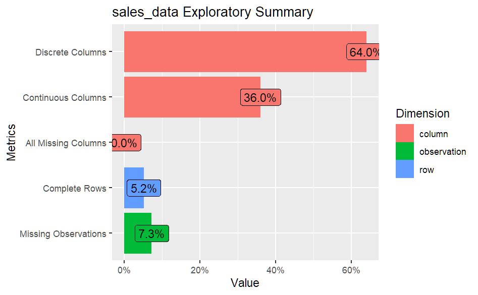

```r
DataExplorer::plot_intro(sales_data , title = "sales_data Exploratory Summary") # check the types of variables
```

## Checking for null

```r
# Manually calculate null counts for each column
null_counts <- sapply(sales_data, function(x) sum(is.na(x)))

# Create a data frame with columns and their respective null counts
null_counts_df <- data.frame(Null_Count = null_counts)

# Print the data frame with the list of columns and their null counts
print(null_counts_df)
```

|  | Null_Count |
| --- | --- |
| ordernumber | 0 |
| quantityordered | 0 |
| priceeach | 0 |
| orderlinenumber | 0 |
| sales | 0 |
| orderdate | 0 |
| status | 0 |
| qtr_id | 0 |
| month_id | 0 |
| year_id | 0 |

[output cut: 15 more lines]

*Observation:* - join address 1 and 2 to cater for nulls in address 2 - state, territory and postalcode is irrelevamt, remove from dataset - Convert ‘orderdate’ to a Date object

## joining adress 1 and 2 to remove null in address 2 as address , creating alias for contact name and change orderdate datatype

```r
# Join the two columns with a space in between
sales_data$address <- paste(sales_data$addressline1, sales_data$addressline2, sep = " ")

# Create an alias column with last name and the first character of the first name
sales_data$contactalias <- paste0(sales_data$contactlastname, " ", str_sub(sales_data$contactfirstname, 1, 1), ".")

# Convert 'orderdate' to a Date object
sales_data$orderdate <- as.Date(sales_data$orderdate, format = "%m/%d/%Y %H:%M")

# Extract the year and month from the order date
sales_data <- sales_data %>%
  mutate(year_month = format(orderdate, "%Y-%m"))
```

## removing irrelevant coluns

```r
sales_cleaned <- sales_data %>%
  select(-orderlinenumber, -productcode, -phone, -addressline1 ,-addressline2,  -state,
         -postalcode, -territory, -contactfirstname, -contactlastname)
```

## Recheck for null

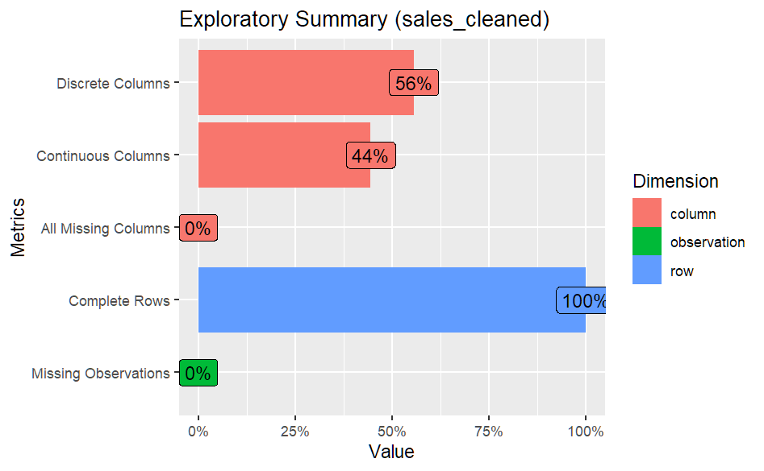

```r
DataExplorer::plot_intro(sales_cleaned , title = "Exploratory Summary (sales_cleaned)") # check the types of variables
```

## Checking for Duplicate

```r
# Count duplicate rows in the entire data frame
total_duplicate_count <- sum(duplicated(sales_cleaned))
total_duplicate_count
```

```
[1] 0
```

```r
# if duplicate exists remove
# sales_cleaned <- sales_cleaned[!duplicated(sales_cleaned), ]
```

# Analysis

## Basic statistical information

```r
skimr::skim(sales_cleaned)
```

```
── Data Summary ────────────────────────
                           Values
Name                       sales_cleaned
Number of rows             2823
Number of columns          18
_______________________
Column type frequency:
  character                9
  Date                     1
  numeric                  8
________________________
Group variables            None
```

|  | skim_variable | n_missing | complete_rate | min | max | empty | n_unique | whitespace |
| --- | --- | --- | --- | --- | --- | --- | --- | --- |
| 1 | status | 0 | 1 | 7 | 10 | 0 | 6 | 0 |
| 2 | productline | 0 | 1 | 5 | 16 | 0 | 7 | 0 |
| 3 | customername | 0 | 1 | 10 | 34 | 0 | 92 | 0 |
| 4 | city | 0 | 1 | 3 | 14 | 0 | 73 | 0 |
| 5 | country | 0 | 1 | 2 | 11 | 0 | 19 | 0 |
| 6 | dealsize | 0 | 1 | 5 | 6 | 0 | 3 | 0 |
| 7 | address | 0 | 1 | 14 | 49 | 0 | 92 | 0 |
| 8 | contactalias | 0 | 1 | 5 | 14 | 0 | 88 | 0 |
| 9 | year_month | 0 | 1 | 7 | 7 | 0 | 29 | 0 |

|  | skim_variable | n_missing | complete_rate | min | max | median | n_unique |
| --- | --- | --- | --- | --- | --- | --- | --- |
| 1 | orderdate | 0 | 1 | 2003-01-06 | 2005-05-31 | 2004-06-15 | 252 |

|  | skim_variable | n_missing | complete_rate | mean | sd | p0 | p25 | p50 | p75 | p100 | hist |
| --- | --- | --- | --- | --- | --- | --- | --- | --- | --- | --- | --- |
| 1 | ordernumber | 0 | 1 | 10258.725115 | 92.0854776 | 10100.00 | 10180.00 | 10262.0 | 10333.5 | 10425.0 | ▇▇▇▇▆ |
| 2 | quantityordered | 0 | 1 | 35.092809 | 9.7414427 | 6.00 | 27.00 | 35.0 | 43.0 | 97.0 | ▂▇▃▁▁ |
| 3 | priceeach | 0 | 1 | 83.658544 | 20.1742765 | 26.88 | 68.86 | 95.7 | 100.0 | 100.0 | ▁▁▂▂▇ |
| 4 | sales | 0 | 1 | 3553.889072 | 1841.8651057 | 482.13 | 2203.43 | 3184.8 | 4508.0 | 14082.8 | ▇▆▂▁▁ |
| 5 | qtr_id | 0 | 1 | 2.717676 | 1.2038781 | 1.00 | 2.00 | 3.0 | 4.0 | 4.0 | ▅▅▁▃▇ |
| 6 | month_id | 0 | 1 | 7.092455 | 3.6566333 | 1.00 | 4.00 | 8.0 | 11.0 | 12.0 | ▅▃▂▂▇ |
| 7 | year_id | 0 | 1 | 2003.815090 | 0.6996702 | 2003.00 | 2003.00 | 2004.0 | 2004.0 | 2005.0 | ▆▁▇▁▃ |
| 8 | msrp | 0 | 1 | 100.715551 | 40.1879117 | 33.00 | 68.00 | 99.0 | 124.0 | 214.0 | ▆▇▆▃▁ |

**Observation**

## Correlation Analysis

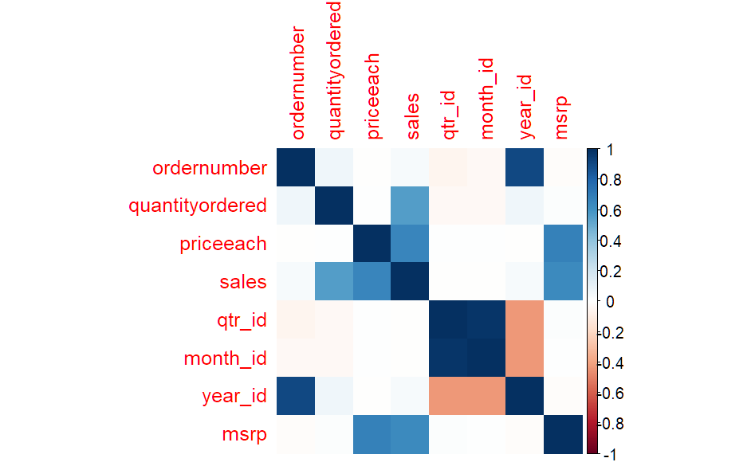

```r
# Calculate the correlation matrix
correlation_matrix <- sales_cleaned %>%
  select_if(is.numeric) %>%  # Select only numeric columns
  cor(method = "pearson")    # You can also use "spearman" for Spearman's correlation

corrplot(correlation_matrix, method = "color")
```

**Observation**

- There is a strong positive correlation (0.6706) between priceeach and msrp, indicating that the price at which an item is sold (priceeach) is strongly associated with the manufacturer’s suggested retail price (msrp).
- There is a moderate positive correlation (0.5514) between quantityordered and sales, indicating that higher quantities ordered are associated with higher sales.

*These correlations provide insights into the relationships between the variables in your dataset and not necessarily causation.*

## Data Analysis

### Sales Overview:

-To Provide an overview of total revenue, total quantity sold, and average price per unit for the given period.

```r
#  total sales and monthly sales of each financial year?  Assuming  financial year starts in April and ends in March:
sales_cleaned <- sales_cleaned %>%
  mutate(
    financial_year = ifelse(month_id >= 4, year_id, year_id - 1)
  )

head(sales_cleaned)
```

| ordernumber | quantityordered | priceeach | sales | orderdate | status | qtr_id | month_id | year_id | productline | msrp | customername | city | country | dealsize | address | contactalias | year_month | financial_year |
| --- | --- | --- | --- | --- | --- | --- | --- | --- | --- | --- | --- | --- | --- | --- | --- | --- | --- | --- |
| 10107 | 30 | 95.70 | 2871.00 | 2003-02-24 | Shipped | 1 | 2 | 2003 | Motorcycles | 95 | Land of Toys Inc. | NYC | USA | Small | 897 Long Airport Avenue NA | Yu K. | 2003-02 | 2002 |
| 10121 | 34 | 81.35 | 2765.90 | 2003-05-07 | Shipped | 2 | 5 | 2003 | Motorcycles | 95 | Reims Collectables | Reims | France | Small | 59 rue de l'Abbaye NA | Henriot P. | 2003-05 | 2003 |
| 10134 | 41 | 94.74 | 3884.34 | 2003-07-01 | Shipped | 3 | 7 | 2003 | Motorcycles | 95 | Lyon Souveniers | Paris | France | Medium | 27 rue du Colonel Pierre Avia NA | Da Cunha D. | 2003-07 | 2003 |
| 10145 | 45 | 83.26 | 3746.70 | 2003-08-25 | Shipped | 3 | 8 | 2003 | Motorcycles | 95 | Toys4GrownUps.com | Pasadena | USA | Medium | 78934 Hillside Dr. NA | Young J. | 2003-08 | 2003 |
| 10159 | 49 | 100.00 | 5205.27 | 2003-10-10 | Shipped | 4 | 10 | 2003 | Motorcycles | 95 | Corporate Gift Ideas Co. | San Francisco | USA | Medium | 7734 Strong St. NA | Brown J. | 2003-10 | 2003 |
| 10168 | 36 | 96.66 | 3479.76 | 2003-10-28 | Shipped | 4 | 10 | 2003 | Motorcycles | 95 | Technics Stores Inc. | Burlingame | USA | Medium | 9408 Furth Circle NA | Hirano J. | 2003-10 | 2003 |

```r
# Group sales data by the financial_year and month_id:

monthly_financial_year_sales <- sales_cleaned %>%
  group_by(financial_year = year_id, quarter= qtr_id, month_id) %>%
  summarise(
    total_sales = sum(sales), .groups = "drop"
  )

monthly_financial_year_sales$month <- month.abb[as.integer(monthly_financial_year_sales$month_id)]
monthly_financial_year_sales$financial_year <- as.factor(monthly_financial_year_sales$financial_year)
monthly_financial_year_sales$quarter <- as.factor(monthly_financial_year_sales$quarter)


monthly_financial_year_sales
```

| financial_year | quarter | month_id | total_sales | month |
| --- | --- | --- | --- | --- |
| 2003 | 1 | 1 | 129753.6 | Jan |
| 2003 | 1 | 2 | 140836.2 | Feb |
| 2003 | 1 | 3 | 174504.9 | Mar |
| 2003 | 2 | 4 | 201609.5 | Apr |
| 2003 | 2 | 5 | 192673.1 | May |
| 2003 | 2 | 6 | 168082.6 | Jun |
| 2003 | 3 | 7 | 187731.9 | Jul |
| 2003 | 3 | 8 | 197809.3 | Aug |
| 2003 | 3 | 9 | 263973.4 | Sep |
| 2003 | 4 | 10 | 568291.0 | Oct |

[output cut: 19 more lines]

```r
NA
```

```r
# total sales
total_revenue <- sum(monthly_financial_year_sales$total_sales)
```

**Observation**

- Total revenue generated across all years is roughly $10M

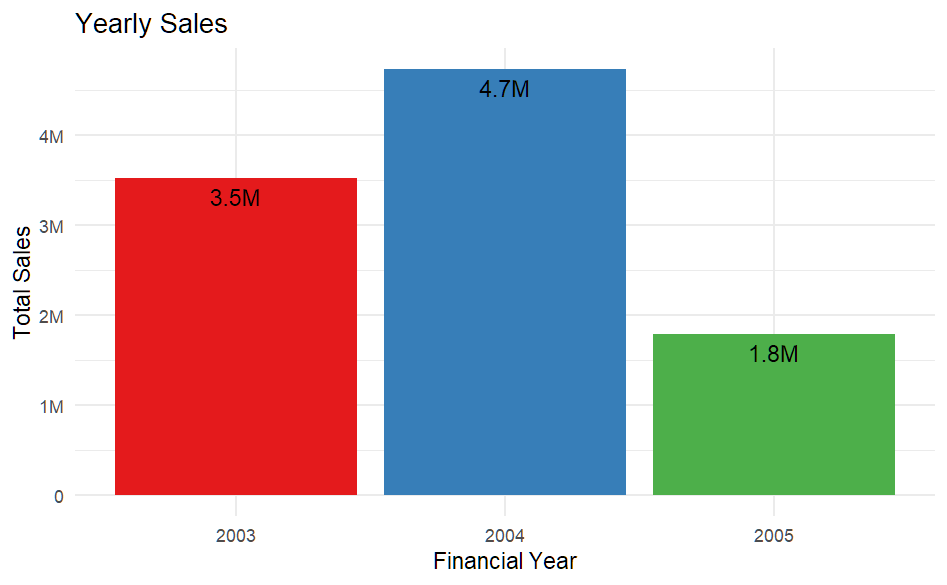

```r
# Calculate total sales for each financial year
yearly_totals <- monthly_financial_year_sales %>%
  group_by(financial_year) %>%
  summarize(total_sales = sum(total_sales))

yearly_sales_plot <- ggplot(monthly_financial_year_sales, aes(x = financial_year, y = total_sales, fill = financial_year)) +
  geom_bar(stat = "identity") +
  labs(
    title = "Yearly Sales",
    x = "Financial Year",
    y = "Total Sales"
  ) +
  scale_fill_brewer(palette = "Set1") +  # Use a predefined color palette
  scale_y_continuous(labels = scales::label_number_si()) +  # Format as currency
  theme_minimal() +  # Apply a minimal theme
  theme(legend.position = "none") +  # Hide the legend
  geom_text(data = yearly_totals, aes(label = scales::label_number_si()(total_sales), vjust = 1.5), size = 4)

# Display the plot
yearly_sales_plot
```

**Observation**

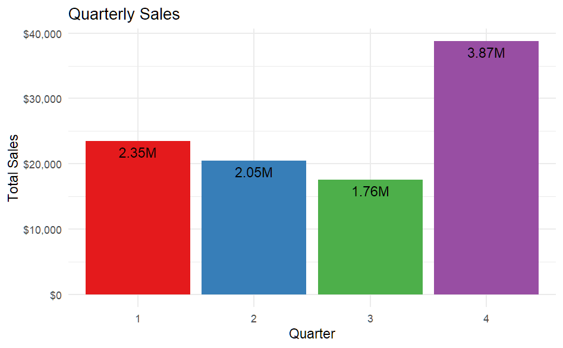

```r
# Calculate total sales for each financial year
quarterly_totals <- monthly_financial_year_sales %>%
  group_by(quarter) %>%
  summarize(total_sales = sum(total_sales))

quarterly_sales_plot <- ggplot(monthly_financial_year_sales, aes(x = quarter, y = total_sales, fill = quarter)) +
  geom_bar(stat = "identity") +
  labs(
    title = "Quarterly Sales",
    x = "Quarter",
    y = "Total Sales"
  ) +
  scale_fill_brewer(palette = "Set1") +  # Use a predefined color palette
  scale_y_continuous(labels = scales::dollar_format(scale = 0.01)) +  # Format as currency
  theme_minimal() +  # Apply a minimal theme
  theme(legend.position = "none") +  # Hide the legend
  geom_text(data = quarterly_totals, aes(label = scales::label_number_si()(total_sales), vjust = 1.5), size = 4)

# Display the plot
quarterly_sales_plot
```

**Observation**

- Overall Qtr 4 has the highest revenue inflow of 3.8M probably being festive period.

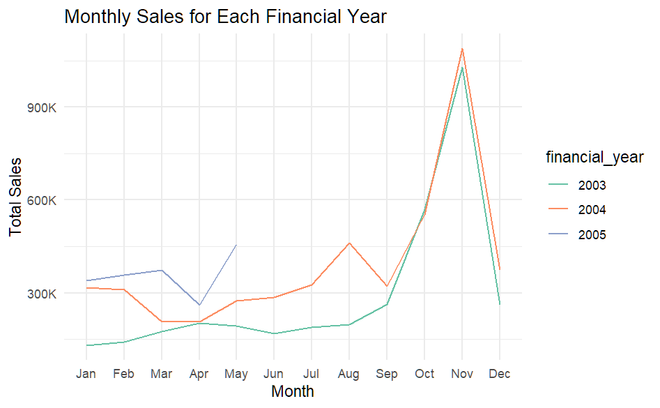

```r
# Create a line plot for monthly sales for each financial years

monthly_financial_year_sales$month <- factor(monthly_financial_year_sales$month, levels = month.abb)

monthly_sales_plot <- ggplot(monthly_financial_year_sales, aes(x = month, y = total_sales, color = financial_year, group = financial_year)) +
  geom_line() +
  labs(
    title = "Monthly Sales for Each Financial Year",
    x = "Month",
    y = "Total Sales"
  ) +
  scale_color_brewer(palette = "Set2") +  # Use a predefined color palette
  scale_y_continuous(labels = scales::label_number_si()) +  # Format as currency
  theme_minimal()



monthly_sales_plot
```

**Observation**

- In 2003, month of Januarry had the least amount of sales whereas month of November had best monthly sales
- In 2004, month of April had the least amount of sales whereas month of November had best monthly sales
- In 2005, month of April had the least amount of sales whereas month of May had best monthly sales

### Product Analysis:

```r
# total unique products
unique_products_count <- sales_cleaned %>%
  distinct(productline) %>% n_distinct()
```

- Total unique products: 7

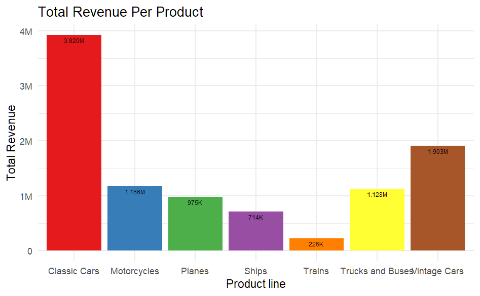

```r
#What product sold the most? Why do you think it sold the most?

productline_sales <- sales_cleaned %>%
  group_by( productline) %>%
  summarise(
    total_sales = sum(sales),
    average_sales = mean(sales),
    avg_price = mean(priceeach),
    median_price = median(priceeach),
    quantity_ordered = sum(quantityordered),
    avg_quantity_ordered = round(mean(quantityordered)),
    msrp = median(msrp),  # MSRP = Manufacturer’s Suggested Retail Price
    .groups = "drop"
  )  %>%
  arrange(desc(total_sales))


 ggplot(productline_sales, aes(x = productline, y = total_sales, fill = productline)) +
  geom_bar(stat = "identity") +
  labs(
    title = "Total Revenue Per Product",
    x = "Product line",
    y = "Total Revenue"
  ) +
  scale_fill_brewer(palette = "Set1") +  # Use a predefined color palette
  scale_y_continuous(labels = scales::label_number_si()) +  # Format as currency
  theme_minimal() +  # Apply a minimal theme
  theme(legend.position = "none") + # Hide the legend
  geom_text(data = productline_sales, aes(label = scales::label_number_si()(total_sales), vjust = 1.5), size = 2)
```

```r
NA
NA
```

- Product line that sold the most: Classic Cars with quantities ordered and a total sale of 4M at 124 average MSRP.

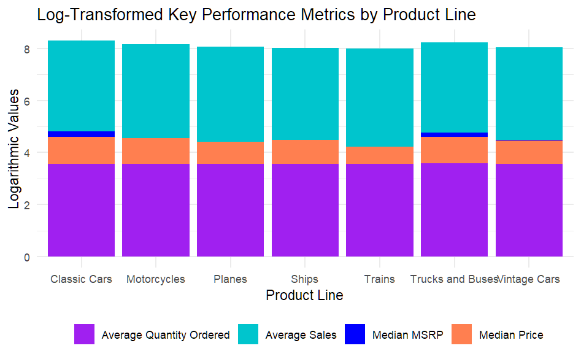

```r
# Create a grouped bar plot for key performance metrics
key_metrics_plot <- ggplot(productline_sales, aes(x = productline)) +
  geom_col(aes(y = log(average_sales), fill = "Average Sales")) +
  geom_col(aes(y = log(msrp), fill = "Median MSRP")) +
  geom_col(aes(y = log(median_price), fill = "Median Price")) +
  geom_col(aes(y = log(avg_quantity_ordered), fill = "Average Quantity Ordered")) +
  scale_fill_manual(values = c("Average Sales" = "turquoise3", "Median MSRP" = "blue", "Median Price" = "coral", "Average Quantity Ordered" = "purple")) +
  labs(
    title = "Log-Transformed Key Performance Metrics by Product Line",
    x = "Product Line",
    y = "Logarithmic Values"
  ) +
  scale_y_continuous(labels = scales::label_number_si()) +
  theme_minimal() +
   theme(legend.title = element_blank(),
        legend.position = "bottom",  # Place the legend below
        legend.direction = "horizontal")  # Display the legend horizontally

key_metrics_plot
```

**Observation**

- Classic Cars, with the highest total sales and average sales, appear to be the best-performing product line in terms of revenue generation, suggesting strong customer demand for these product lines.
- Trains have the lowest sales performance and price metrics among the product lines
- Classic Cars and Trucks and Buses have the highest average prices/ MSRP, indicating premium pricing for these products.
- Trucks and Buses, despite having the highest median price/ average price/ has a lower total sales volume, indicating a higher price point for their products.
- The average quantity ordered is consistent across all product lines at 35, suggesting a standardized order quantity and may suggest consistent customer behavior..

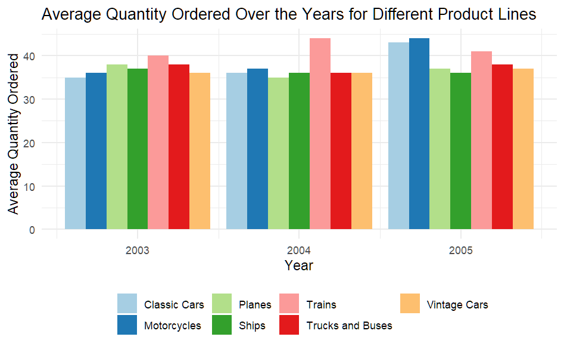

```r
product_performance <- sales_cleaned %>%
  group_by( year_id,qtr_id ,productline) %>%
  summarise(
    avg_quantity_ordered = round(mean(quantityordered)),
    average_sales = mean(sales),
    avg_price = mean(priceeach),
    avg_msrp = mean(msrp),  # MSRP = Manufacturer’s Suggested Retail Price
    .groups = "drop"
  )  %>%
  arrange(desc(average_sales))

# Create a bar plot for the "Average Quantity Ordered" metric for all product lines over the years
ggplot(product_performance, aes(x = year_id, y = avg_quantity_ordered, fill = productline)) +
  geom_bar(stat = "identity", position = "dodge") +
  labs(
    title = "Average Quantity Ordered Over the Years for Different Product Lines",
    x = "Year",
    y = "Average Quantity Ordered"
  ) +
  scale_fill_brewer(palette = "Paired") +  # Use a predefined color palette
  theme_minimal()+
  theme(legend.title = element_blank(),
        legend.position = "bottom",  # Place the legend below
        legend.direction = "horizontal")  # Display the legend horizontally
```

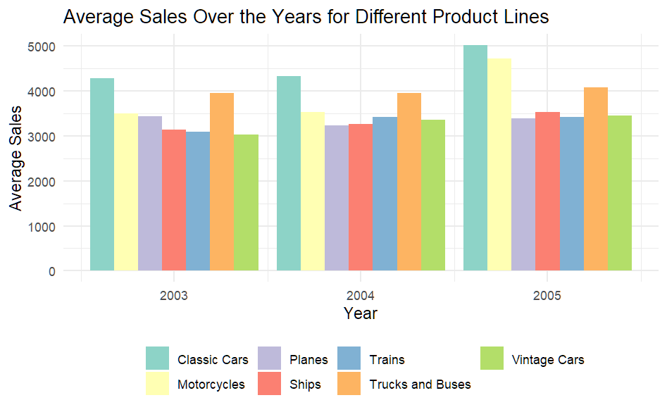

```r
# Create a plot for the "Average Sales" metric for all product lines over the years
ggplot(product_performance, aes(x = year_id, y = average_sales, fill = productline)) +
  geom_bar(stat = "identity", position = "dodge") +
  labs(
    title = "Average Sales Over the Years for Different Product Lines",
    x = "Year",
    y = "Average Sales"
  ) +
  scale_fill_brewer(palette = "Set3") +  # Use a predefined color palette
  theme_minimal()+
  theme(legend.title = element_blank(),
        legend.position = "bottom",  # Place the legend below
        legend.direction = "horizontal")  # Display the legend horizontally
```

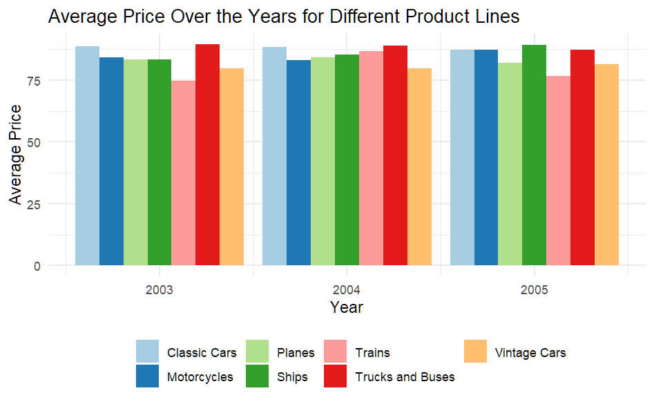

```r
# Create a plot for the "Average Price" metric for all product lines over the years
ggplot(product_performance, aes(x = year_id, y = avg_price, fill = productline)) +
  geom_bar(stat = "identity", position = "dodge") +
  labs(
    title = "Average Price Over the Years for Different Product Lines",
    x = "Year",
    y = "Average Price"
  ) +
  scale_fill_brewer(palette = "Paired") +  # Use a predefined color palette
  theme_minimal()+
  theme(legend.title = element_blank(),
        legend.position = "bottom",  # Place the legend below
        legend.direction = "horizontal")  # Display the legend horizontally
```

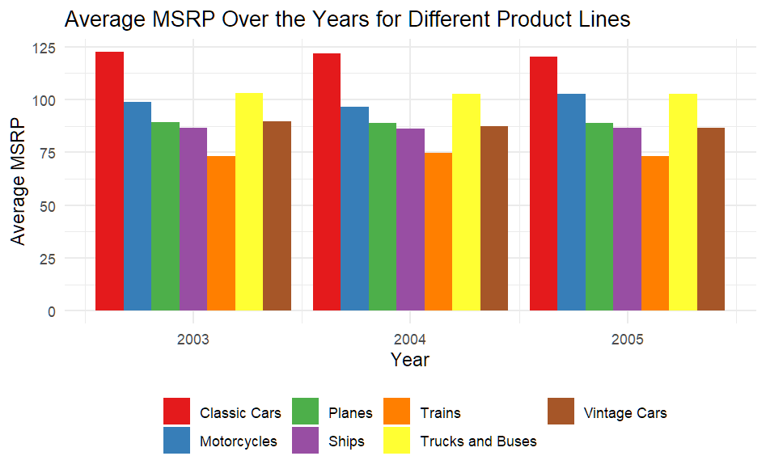

```r
# Create a plot for the "Average MSRP" metric for all product lines over the years
ggplot(product_performance, aes(x = year_id, y = avg_msrp, fill = productline)) +
  geom_bar(stat = "identity", position = "dodge") +
  labs(
    title = "Average MSRP Over the Years for Different Product Lines",
    x = "Year",
    y = "Average MSRP"
  ) +
  scale_fill_brewer(palette = "Set1") +  # Use a predefined color palette
  theme_minimal()+
  theme(legend.title = element_blank(),
        legend.position = "bottom",  # Place the legend below
        legend.direction = "horizontal")  # Display the legend horizontally
```

**Insights**

```r
# Calculate total sales for each product line in each quarter
productline_quarter_sales <- sales_cleaned %>%
  group_by(productline, qtr_id) %>%
  summarise(total_sales = sum(sales), .groups = "drop")

# Find the quarter with the highest total sales for each product line
best_quarter <- productline_quarter_sales %>%
  group_by(productline) %>%
  slice_max(order_by = total_sales)%>%
  arrange(desc(total_sales))

# Print the results
print(best_quarter)
```

| productline | qtr_id | total_sales |
| --- | --- | --- |
| Classic Cars | 4 | 1527449.57 |
| Vintage Cars | 4 | 766643.91 |
| Trucks and Buses | 4 | 478821.37 |
| Motorcycles | 4 | 410985.83 |
| Planes | 4 | 350539.36 |
| Ships | 4 | 246947.33 |
| Trains | 4 | 93392.64 |

```r
NA
```

**Observation**

- Classic Cars performed exceptionally well in quarter 4 with total sales of approximately 1,527,449.57, while Vintage Cars,Trucks and Buses , Motorcycles, and Planes also showed strong sales performance.
- Trains had the lowest total sales, indicating a comparatively weaker quarter for that product line.
- Overall, in the 4th quarter of each year all Products had maximum sales.The reason may be arrival of the Chirstmas holidays

**Insight:**

1. *Seasonal Variations:* There are significant quarterly variations in sales for different product lines. These variations might be due to seasonal factors, customer preferences, or other external influences.
2. *Strong Performers:* Classic Cars consistently outperformed other product lines in terms of total sales across all quarters. This product line appears to have a strong and stable customer base.
3. *Product Line Performance:* Vintage Cars and Trucks and Buses also demonstrated strong performance, with high total sales in quarter 4. This suggests that these product lines may have high demand during that period.
4. *Low Performer:* Trains consistently had the lowest total sales among all the product lines. This could indicate that the Trains product line may require additional marketing or strategic changes to boost sales.

*- data suggests that customers’ preferences and buying patterns might vary across different product lines and quarters. Understanding these variations can help in making informed business decisions and marketing strategies.*

*- Businesses might consider implementing seasonal marketing strategies and product promotions to leverage the quarterly variations and boost sales during specific periods.*

*- Businesses should adjust their inventory and production planning based on these seasonal variations to meet the changing demand for different product lines*.

### Customer and Region Analysis:

```r
# total unique customers
unique_customers_count <- sales_cleaned %>%
  distinct(customername) %>% n_distinct()
```

- There are 92 unique customers in the dataset

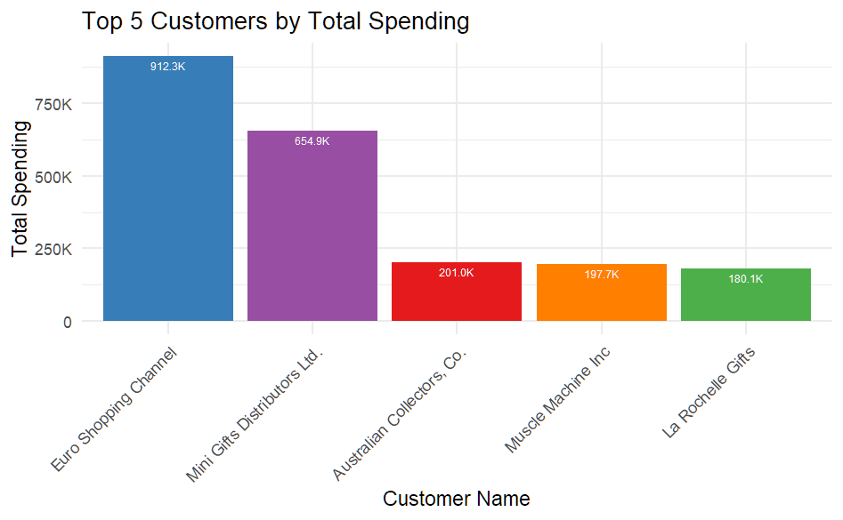

```r
# Group the data by customer_id and calculate the total spending for each customer
customer_spending <- sales_cleaned %>%
  group_by(customername, city) %>%
  summarise(total_spending = sum(sales)) %>%
  arrange(desc(total_spending))
# Get the top 5 spending customers
top_5_customers <- head(customer_spending, 5)

ggplot(top_5_customers, aes(x = reorder(customername, -total_spending), y = total_spending, fill = customername)) +
  geom_bar(stat = "identity") +
  labs(
    title = "Top 5 Customers by Total Spending",
    x = "Customer Name",
    y = "Total Spending"
  ) +
  scale_fill_brewer(palette = "Set1") +  # Use a predefined color palette
  scale_y_continuous(labels = scales::label_number_si()) +  # Format as currency
  theme_minimal() +
  theme(axis.text.x = element_text(angle = 45, hjust = 1))+
  theme(legend.position = "none") + # Hide the legend
  geom_text(data = top_5_customers, aes(label = scales::label_number_si()(total_spending), vjust = 1.5), size = 2, color = "white")
```

**Observations:**

- Clearly the the most valuable customer is Euro Shopping Channel from the city of Madrid with a total spend of 912K

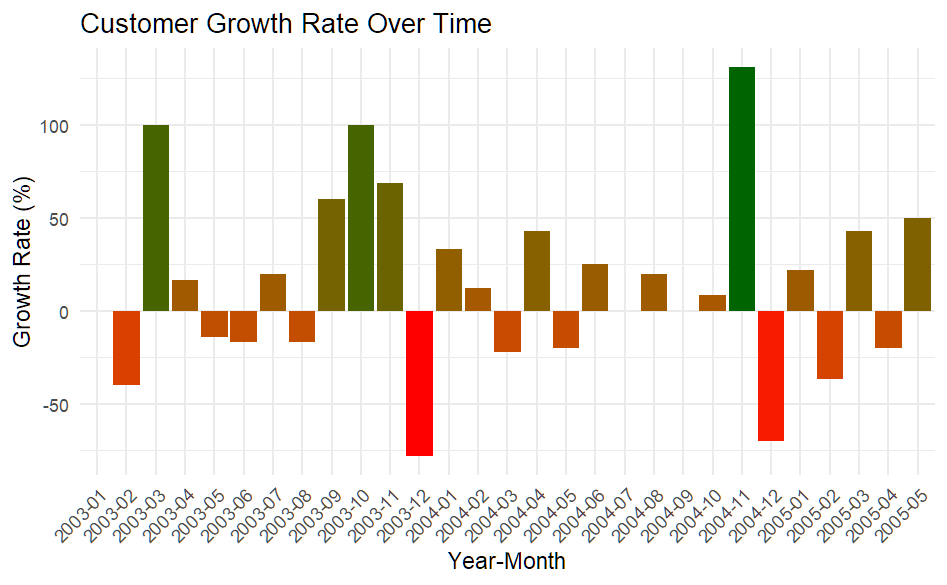

```r
# Calculate customer growth rate
customer_growth <- sales_cleaned %>%
  group_by(year_month) %>%
  summarize(
    customers = n_distinct(customername)
  ) %>%
  mutate(
    growth_rate = (customers - lag(customers)) / lag(customers) * 100
  )

# Visualize customer growth rate
 ggplot(customer_growth, aes(x = year_month, y = growth_rate, fill = growth_rate )) +
  geom_bar(stat = "identity") +
  labs(
    title = "Customer Growth Rate Over Time",
    x = "Year-Month",
    y = "Growth Rate (%)"
  ) +
  scale_fill_gradient(low = "red", high = "darkgreen", na.value = "transparent") +  # Adjust the color scale
   theme_minimal() +
  theme(legend.position = "none") +
  theme(axis.text.x = element_text(angle = 45, hjust = 1))
```

**Observation**

- November 2004 had the highest number of customers with 30 customers and a growth rate of 130.77%, while
- February 2005 had the lowest number of customers with 7 customers and a growth rate of -36.36% in the dataset.

**Insights:**

1. *Monthly Customer Growth:* Growth rates can be both positive and negative, indicating periods of customer acquisition and attrition.
2. *Seasonal Trends:* Looking at the growth rates, there are fluctuations from one month to another. For example, there is a significant increase in customer count from October 2003 to November 2003, with a growth rate of 68.75%. However, in December 2003, there is a sharp decline in customer count, with a negative growth rate of -77.78%.
3. *Yearly Patterns:* The data spans multiple years, and there are noticeable yearly patterns. For instance, between November 2003 and November 2004, there’s substantial customer growth, with a peak growth rate of 130.77%. The year 2005 also starts with positive customer growth.
4. *Negative Growth:* Several months exhibit negative growth rates, which may indicate a decline in customer numbers or customer churn during those periods.
5. *Yearly Cycles:* There are yearly cycles where customer counts may peak during certain months, potentially aligning with holidays, promotions, or other factors influencing customer behavior.

*Understanding these customer growth trends can help businesses identify opportunities for expansion and areas where they need to address customer retention and growth strategies.*

#### Regional Analysis

```r
# total unique country and cities
unique_country_count <- sales_cleaned %>%
  distinct(country) %>% n_distinct()

unique_city_count <- sales_cleaned %>%
  distinct(city) %>% n_distinct()
```

- There are 19 unique countries with 73 unique cities

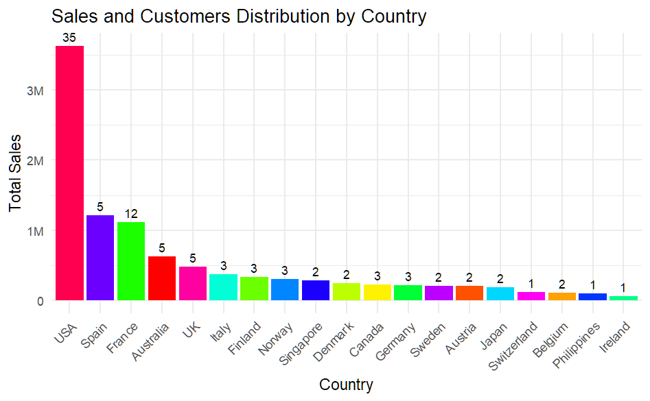

```r
# customer and sales distribution by country
country_sales <- sales_cleaned %>%
  group_by(country) %>%  # Change 'City' to 'Country' if needed
  summarize(totalSales = sum(sales),
            totalcustomers= n_distinct(customername), .groups = "drop")

ggplot(country_sales, aes(x = reorder(country, -totalSales), y = totalSales, fill= country)) +
  geom_bar(stat = "identity") +
   geom_text(aes(label = totalcustomers), vjust = -0.5, size = 3) +  # Add total customers as labels
   labs(
    title = "Sales and Customers Distribution by Country",
    x = "Country",
    y = "Total Sales"
  ) +
  #scale_fill_brewer(palette = "viridis") +
  scale_fill_manual(values = rainbow(length(unique(country_sales$country)))) +
  scale_y_continuous(labels = scales::label_number_si()) +  # Format as currency
  theme_minimal() +
  theme(legend.position = "none") +
  theme(axis.text.x = element_text(angle = 45, hjust = 1))
```

**Observations:**

- USA had the best sales in the world with highest number of customers (35) followed by Spain (5) and France (12).

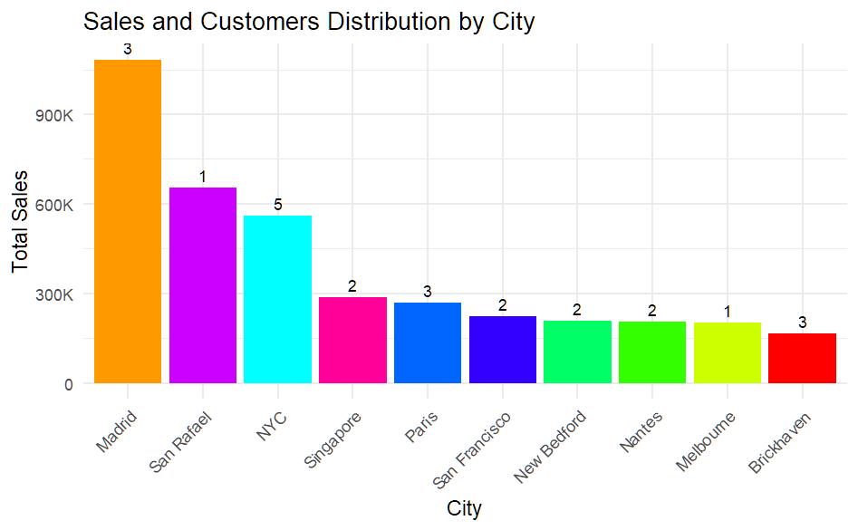

```r
# customer and sales distribution by city
city_sales <- sales_cleaned %>%
  group_by(city) %>%  # Change 'City' to 'Country' if needed
  summarize(totalSales = sum(sales),
            totalcustomers= n_distinct(customername), .groups = "drop")

# Identify top 10 cities with the highest sales
top_cities <- city_sales %>%
  arrange(desc(totalSales)) %>%
  head(10)

ggplot(top_cities, aes(x = reorder(city, -totalSales), y = totalSales, fill= city)) +
  geom_bar(stat = "identity") +
   geom_text(aes(label = totalcustomers), vjust = -0.5, size = 3) +  # Add total customers as labels
   labs(
    title = "Sales and Customers Distribution by City",
    x = "City",
    y = "Total Sales"
  ) +
  #scale_fill_brewer(palette = "viridis") +
  scale_fill_manual(values = rainbow(length(unique(top_cities$city)))) +
  scale_y_continuous(labels = scales::label_number_si()) +  # Format as currency
  theme_minimal() +
  theme(legend.position = "none") +
  theme(axis.text.x = element_text(angle = 45, hjust = 1))
```

**Observations:**

- City of Madrid had the best sales in the world followed by San Rafael and New York City.

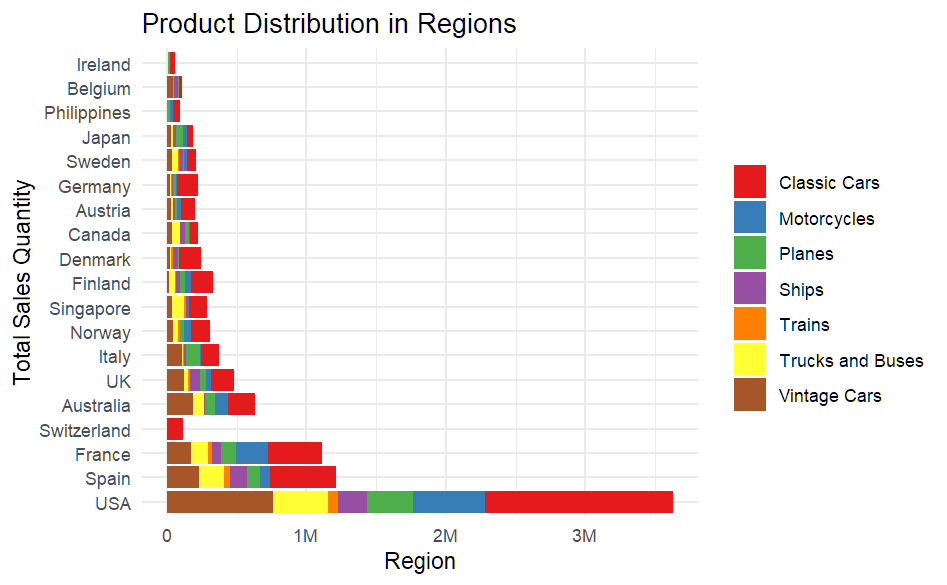

```r
product_region_data <- sales_cleaned %>%
  group_by(productline, country) %>%
  summarize(total_sales = sum(sales),.groups = "drop")

# Create a bar plot to visualize the distribution of products in regions
ggplot(product_region_data, aes(x = total_sales , y = reorder(country, -total_sales), fill = productline)) +
  geom_bar(stat = "identity") +
  labs(
    title = "Product Distribution in Regions",
    x = "Region",
    y = "Total Sales Quantity"
  ) +
  scale_fill_brewer(palette = "Set1") +  # You can choose a color palette
  scale_x_continuous(labels = scales::label_number_si()) +  # Format as currency
  theme_minimal() +
  theme(legend.position = "right", legend.title = element_blank())
```

**Observations/Insights**

1. Likewise, The USA is a significant market for all product lines, showing a high level of sales across the board.
2. France, Spain, and some European countries are also notable markets for various product lines.they showcases robust sales figures for Classic Cars and Vintage Cars and exhibit a significant customer base for these product lines, suggesting that tailored marketing campaigns and localized strategies can further capitalize on these market opportunities.
3. Several countries have relatively lower total sales, such as Austria and Belgium for Classic Cars, or Ireland and the Philippines for Trains. These regions present untapped potential for market expansion and growth.
4. By recognizing these regional differences in product line performance, businesses can tailor their efforts to capitalize on specific market strengths and address weaknesses effectively. A targeted and region-specific strategy can lead to more successful market penetration and revenue generation.”

## Shipping Analys:

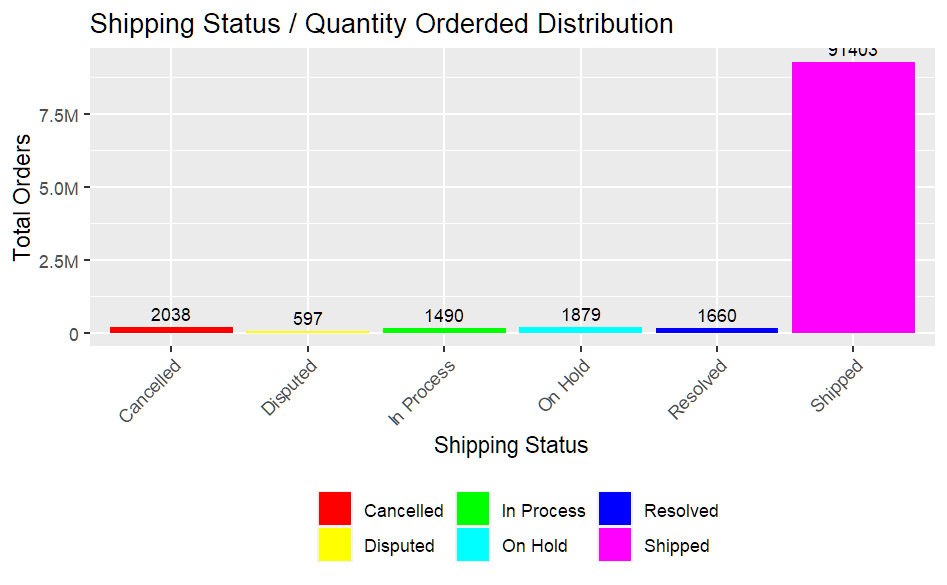

```r
shippingstatus_data <- sales_cleaned %>%
  group_by(status) %>%
  summarize(total_sales = sum(sales),
            total_qty= sum(quantityordered), .groups = "drop")

ggplot(shippingstatus_data, aes(x = status, y = total_sales , fill = status)) +
  geom_bar(stat = "identity") +
  geom_text(aes(label = total_qty), vjust = -0.5, size = 3) +  # Add total order quantity
  labs(
    title = "Shipping Status / Quantity Orderded Distribution ",
    x = "Shipping Status",
    y = "Total Orders"
  ) +
   scale_fill_manual(values = rainbow(length(unique(sales_cleaned$status))))+
   scale_y_continuous(labels = scales::label_number_si()) +  # Format as currency
   theme(axis.text.x = element_text(angle = 45, hjust = 1))+
  theme(legend.title = element_blank(),
        legend.position = "bottom",  # Place the legend below
        legend.direction = "horizontal")  # Display the legend horizontally
```

```r
 # facet_wrap(~shipping_speed)
```

**Observations:**

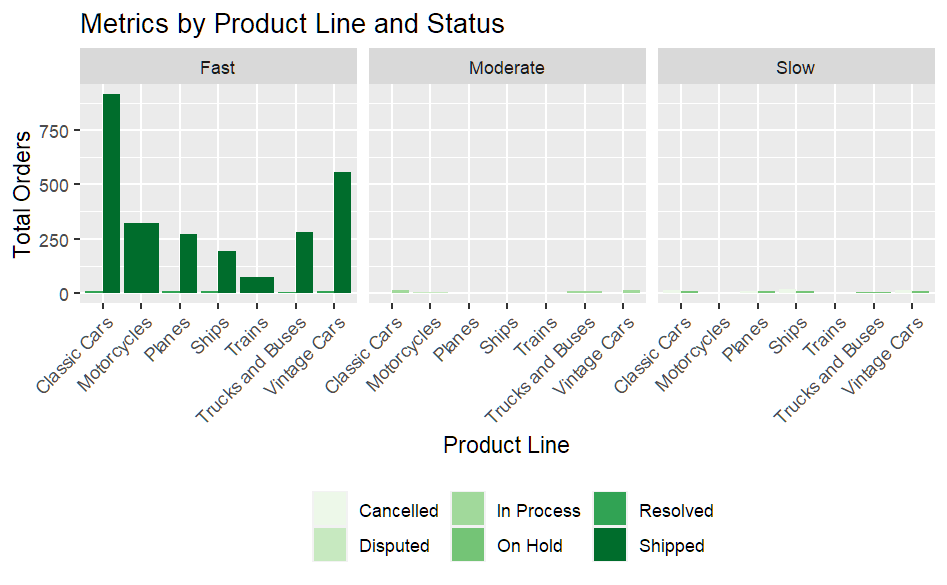

```r
# Create a new variable to categorize shipping speed
sales_cleaned <- sales_cleaned %>%
  mutate(
  shipping_speed = case_when(
      status %in% c("Shipped", "Resolved") ~ "Fast",
      status %in% c("Disputed", "In Process") ~ "Moderate",
      status %in% c("Cancelled", "On Hold") ~ "Slow",
      TRUE ~ "Other"
    )
  )

# Calculate shipping time based on previous order within the same speed category
sales_cleaned <- sales_cleaned %>%
  arrange(customername, orderdate) %>%
  group_by(customername, shipping_speed) %>%
  mutate(
    shipping_time = as.numeric(difftime(orderdate, lag(orderdate, default = first(orderdate)), units = "days"))
  )

# Shipping Speed Analysis
shippingspeed_analysis <- sales_cleaned %>%
  group_by(productline, status, shipping_speed) %>%
  summarise(
    total_orders = n(),
    avg_sales = mean(sales),
    avg_shipping_time = mean(shipping_time, na.rm = TRUE)
    ,.groups = "drop" # Calculate average shipping time
  )

# Visualize the Shipping Speed Analysis per productline
ggplot(shippingspeed_analysis, aes(x = productline, y = total_orders, fill = status)) +
  geom_bar(stat = "identity", position = "dodge") +
  facet_wrap(~shipping_speed) +  # Create facets for each metric
  labs(
    title = "Metrics by Product Line and Status",
    x = "Product Line",
    y = "Total Orders"
  ) +
  scale_fill_brewer(palette = "paired") +  # Adjust the color palette
   theme(axis.text.x = element_text(angle = 45, hjust = 1))+
   theme(legend.title = element_blank(),
        legend.position = "bottom",  # Place the legend below
        legend.direction = "horizontal")  # Display the legend horizontally
```

**Observations:**

- Fast shipping speeds are associated with “Resolved” and “Shipped” statuses, with “Shipped” having the highest quantity.
- “Cancelled” orders have the slowest shipping speed and should be addressed to potentially increase revenue.
- “Resolved” and “Shipped” statuses tend to have higher average sales, while “Disputed” and “On Hold” statuses have relatively lower average sales.
- Notably, “Cancelled” orders are categorized as “Slow,” and this status indicates that these orders were not shipped.
- “Shipped” orders have a moderate average shipping time.
- Notably, all product lines have a fast shipping speed

## Dealsize Analys:

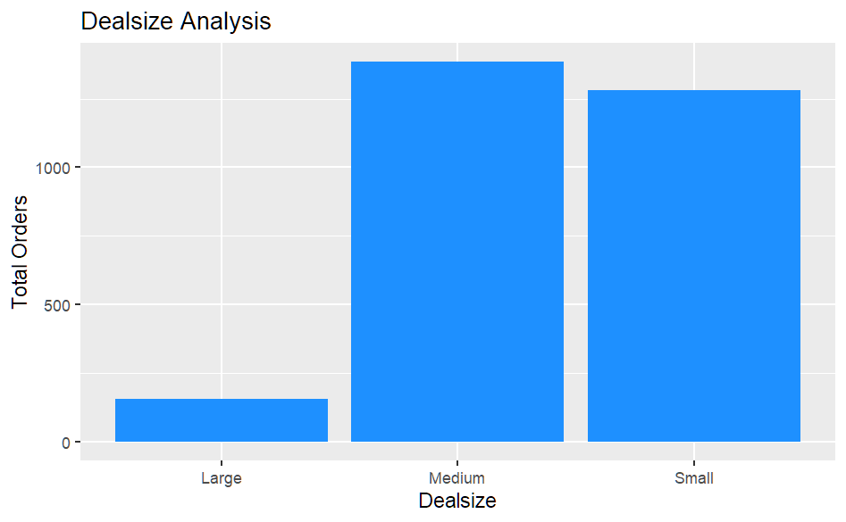

```r
# Dealsize Analysis
dealsize_analysis <- sales_cleaned %>%
  group_by(dealsize) %>%
  summarise(
    total_orders = n()
  )

ggplot(dealsize_analysis, aes(x = dealsize, y = total_orders)) +
  geom_bar(stat = "identity", fill = "dodgerblue") +
  labs(
    title = "Dealsize Analysis",
    x = "Dealsize",
    y = "Total Orders"
  )
```

**Observations:**

- “Medium” and “Small” deals are the most popular in terms of order quantity, indicating that customers tend to prefer these deal sizes.
- “Large” deals, while having a lower number of orders, may have a higher total value per order, as they are less frequent but potentially more substantial.
- This information can be useful for tailoring marketing and sales strategies based on deal size preferences.

```r
# save cleaned df to  file
write.csv(sales_cleaned, "sales_cleaned.csv", row.names = FALSE)
```

# Summary

**Time Trends:**

**Product Line and Status Analysis:**

**Customer and Regional Insights:**

**Deal Size and Shipping Status Analysis :**

- Customers tend to prefer “Medium” and “Small” deals over “Large” deals, as indicated by the higher number of orders for these deal sizes.
- Order statuses vary, with “Shipped” being the most common, while other statuses like “Cancelled” and “Disputed” also exist but with minor sales.

*In summary, this dataset offers valuable insights into customer behavior, product performance across regions, and trends over time. These insights can be leveraged to make informed decisions, develop effective marketing strategies, and identify growth opportunities in various markets.*

**Understanding the unique characteristics of each product line and region is key to optimizing sales and achieving business goals.**